# Лабораторная работа № 5

Основы администрирования операционных систем

Иванов Сергей Владимирович, НПИбд-01-23

Российский университет дружбы народов, Москва, Россия

5 октября 2024

## Цель работы

Получить навыки управления системными службами операционной системы посредством systemd.

## Задание

1. Выполнить основные операции по запуску, определению статуса, добавлению (удалению) в автозапуск службы Very Secure FTP
2. Продемонстровать навыки по разрешению конфликтов юнитов для служб firewalld и iptables
3. Продемонстрировать навыки работы с изолированными целями

# Выполнение работы

## Статус службы Very Secure FTP

Проверим статус службы Very Secure FTP

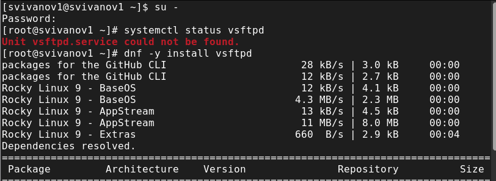

Статус службы Very Secure FTP

## Установка и запуск Very Secure

Установим и запустим службу Very Secure FTP

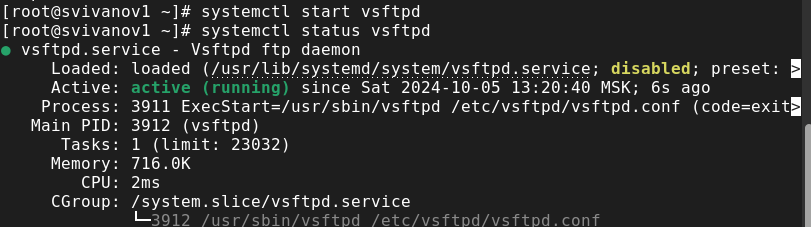

Установка и запуск Very Secure

## Добавляем в автозапуск

Добавим службу Very Secure FTP в автозапуск при загрузке операционной системы и проверим ее статус.

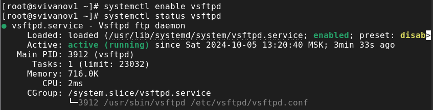

Добавляем в автозапуск

## Убираем из автозапуска

Удалим службу из автозапуска и проверим её статус.

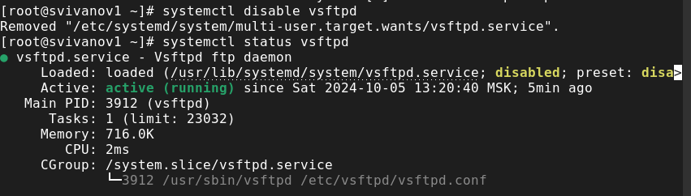

Убираем из автозапуска

## Символические ссылки

Выведем на экран символические ссылки, ответственные за запуск различных сервисов

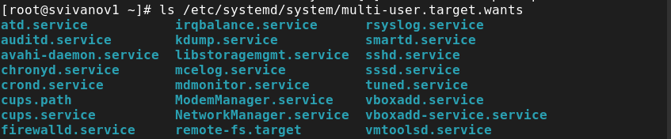

Символические ссылки

## Выводим символические ссылки

Снова добавим службу в автозапуск и выведем на экран символические ссылки

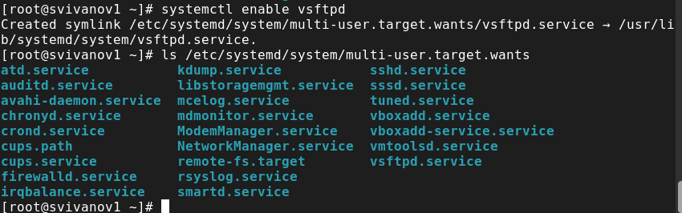

Выводим символические ссылки

## Статус Very Secure

Снова проверим статус службы. Теперь мы видим, что для файла юнита состояние изменено на enabled.

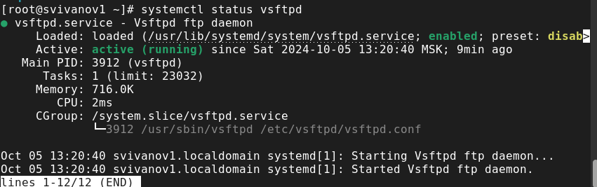

Статус Very Secure

## Список зависимостей юнита

Выведем на экран список зависимостей юнита

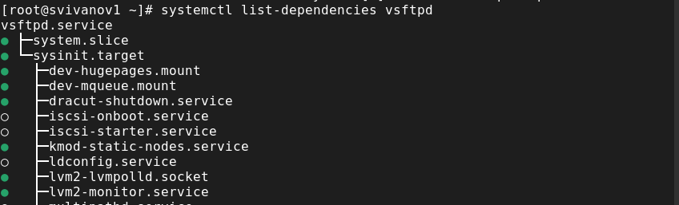

Список зависимостей юнита

## Список юнитов которые зависят от данного

Выведем на экран список юнитов, которые зависят от данного юнита

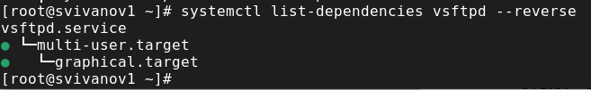

Список юнитов которые зависят от данного

## Установка iptables

Получим полномочия администратора. Установим iptables

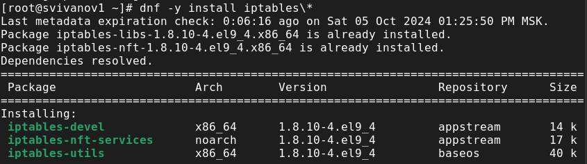

Установка iptables

## Проверка статусов

Проверим статус firewalld

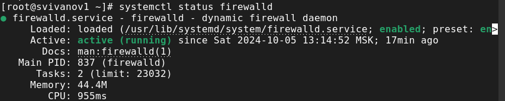

Проверка статусов

## Проверка статусов

Проверим статус iptables

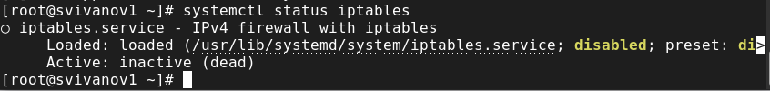

Проверка статусов

## Запуск служб

Попробуем запустить firewalld и iptables. Видим, что при запуске одной службы вторая дезактивируется или не запускается.

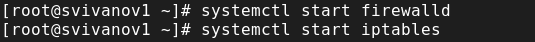

Запуск служб

## Настройки конфликтов

Введем cat /usr/lib/systemd/system/firewalld.service и опишем настройки конфликтов для этого юнита при наличии.

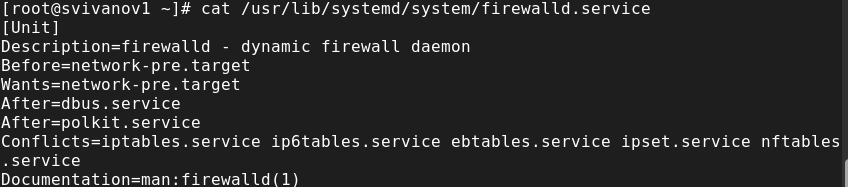

Настройки конфликтов

## Настройки конфликтов

Введем cat /usr/lib/systemd/system/iptables.service и опишем настройки конфликтов для этого юнита.

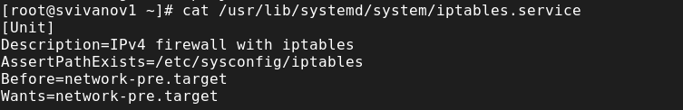

Настройки конфликтов

Выгрузим службу iptables и загрузим firewalld. Заблокируем запуск iptables, попробуем его запустить. Попробуем добавить iptables в автозапуск.

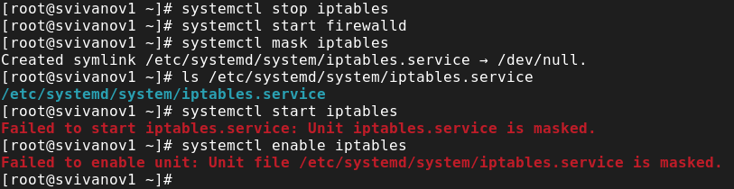

## Загруженные цели

Получим список всех активных загруженных целей

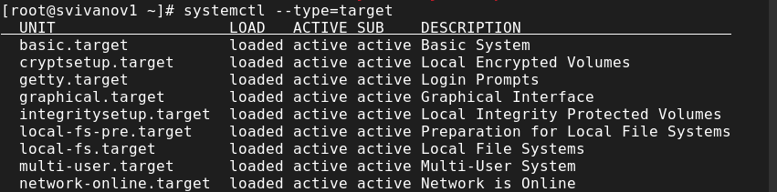

Загруженные цели

## Список всех целей

Получим список всех целей

[figure not shown]

Список всех целей

## Цели которые можно изолировать

Перейдем в каталог systemd и найдем список всех целей, которые можно изолировать

[figure not shown]

Цели которые можно изолировать

## Перезапуск

Переключим операционную систему в режим восстановления и перезапустим операционную систему следующим образом

[figure not shown]

Перезапуск

## Текстовый и графический режим

Перегрузим систему командой reboot. Убедимся, что система загрузилась в текстовом режиме. Для запуска по умолчанию графического режима введем команду. Перегрузим систему командой reboot. Убедимся, что система загрузилась в графическом режиме.

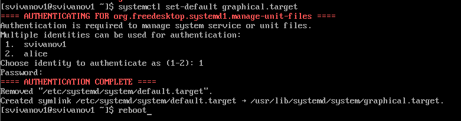

Текстовый и графический режим

# Вывод

## Вывод

В ходе выполнения лабораторной работы были получены навыки управления c системными службами операционной системы посредством systemd.

## Список литературы

https://esystem.rudn.ru/mod/page/view.php?id=1098933